# Chromatin marks plots

Looking at chromatin marks for each of the clusters

Defining source, libraries and options

```r
source("cluster_analysis_functions.R")
library(easystats)
library(broom)
options(scipen = 0)
```

Importing datasets

The marks table was created for capped and uncapped values (the latter only to be used for colouring the umaps). Linkings of marks to clusters happens in the script series umap_20_01_20_unccapped_marks and was exported from there.

```r
#read_tsv("../data/clusters_20_capped_marks_220517.txt") -> clusters_capped_marks
read_tsv("../data/clusters_20_uncapped_marks_220517.txt") -> clusters_uncapped_marks
#read_tsv("../data/pluripotency_exit_RNA_Epi_and_EB_log2RPKM.txt") -> expression_import
```

```r
clusters_uncapped_marks %>%
  rename_with(~gsub("H3K27Ac", "H3K27ac",.)) -> marks
colnames(marks)
```

```
  [1] "interaction_ID"            "V1"                        "V2"                        "bait_ID"
  [5] "oe_ID"                     "bait_gene"                 "oe_gene"                   "CHiC_DNMT_KO_Epi"
  [9] "CHiC_DNMT_KO_ES"           "CHiC_DNMT_WT_Epi"          "CHiC_DNMT_WT_ES"           "CHiC_TET_KO_Epi"
 [13] "CHiC_TET_KO_ES"            "CHiC_TET_WT_Epi"           "CHiC_TET_WT_ES"            "bait_mC_DNMT_WT_ES"
 [17] "bait_mC_DNMT_WT_Epi"       "bait_mC_TET_WT_ES"         "bait_mC_TET_WT_Epi"        "bait_mC_TET_KO_ES"
 [21] "bait_mC_TET_KO_Epi"        "oe_mC_DNMT_WT_ES"          "oe_mC_DNMT_WT_Epi"         "oe_mC_TET_WT_ES"
 [25] "oe_mC_TET_WT_Epi"          "oe_mC_TET_KO_ES"           "oe_mC_TET_KO_Epi"          "bait_hmC_TET_WT_ES"
 [29] "bait_hmC_TET_WT_Epi"       "bait_hmC_DNMT_WT_Epi"      "bait_ATAC_DNMT_KO_Epi"     "bait_ATAC_DNMT_KO_ES"
 [33] "bait_ATAC_DNMT_WT_Epi"     "bait_ATAC_DNMT_WT_ES"      "bait_ATAC_TET_KO_Epi"      "bait_ATAC_TET_KO_ES"
 [37] "bait_ATAC_TET_WT_Epi"      "bait_ATAC_TET_WT_ES"       "bait_CTCF_DNMT_KO_Epi"     "bait_CTCF_DNMT_KO_ES"
 [41] "bait_CTCF_DNMT_WT_Epi"     "bait_CTCF_DNMT_WT_ES"      "bait_CTCF_TET_KO_Epi"      "bait_CTCF_TET_KO_ES"
 [45] "bait_CTCF_TET_WT_Epi"      "bait_CTCF_TET_WT_ES"       "bait_H3K27ac_DNMT_KO_Epi"  "bait_H3K27ac_DNMT_KO_ES"
 [49] "bait_H3K27ac_DNMT_WT_Epi"  "bait_H3K27ac_DNMT_WT_ES"   "bait_H3K27ac_TET_KO_Epi"   "bait_H3K27ac_TET_KO_ES"
 [53] "bait_H3K27ac_TET_WT_Epi"   "bait_H3K27ac_TET_WT_ES"    "bait_H3K27me3_DNMT_KO_Epi" "bait_H3K27me3_DNMT_KO_ES"
 [57] "bait_H3K27me3_DNMT_WT_Epi" "bait_H3K27me3_DNMT_WT_ES"  "bait_H3K27me3_TET_KO_Epi"  "bait_H3K27me3_TET_KO_ES"
```

[output cut: 22 more lines]

Getting some stats for Figure 3

Figure 3a, Dnmt TKO - WT

```r
marks %>%
  filter(cluster_ID == "cluster16") %>%
  select(contains("Epi")) -> cluster16_Epi

head(cluster16_Epi)
```

| CHiC_DNMT_KO_Epi | CHiC_DNMT_WT_Epi | CHiC_TET_KO_Epi | CHiC_TET_WT_Epi | bait_mC_DNMT_WT_Epi | bait_mC_TET_WT_Epi | bait_mC_TET_KO_Epi | oe_mC_DNMT_WT_Epi | oe_mC_TET_WT_Epi | oe_mC_TET_KO_Epi | bait_hmC_TET_WT_Epi | bait_hmC_DNMT_WT_Epi | bait_ATAC_DNMT_KO_Epi | bait_ATAC_DNMT_WT_Epi | bait_ATAC_TET_KO_Epi | bait_ATAC_TET_WT_Epi | bait_CTCF_DNMT_KO_Epi | bait_CTCF_DNMT_WT_Epi | bait_CTCF_TET_KO_Epi | bait_CTCF_TET_WT_Epi | bait_H3K27ac_DNMT_KO_Epi | bait_H3K27ac_DNMT_WT_Epi | bait_H3K27ac_TET_KO_Epi | bait_H3K27ac_TET_WT_Epi | bait_H3K27me3_DNMT_KO_Epi | bait_H3K27me3_DNMT_WT_Epi | bait_H3K27me3_TET_KO_Epi | bait_H3K27me3_TET_WT_Epi | bait_H3K4me1_DNMT_KO_Epi | bait_H3K4me1_DNMT_WT_Epi | … |
| --- | --- | --- | --- | --- | --- | --- | --- | --- | --- | --- | --- | --- | --- | --- | --- | --- | --- | --- | --- | --- | --- | --- | --- | --- | --- | --- | --- | --- | --- | --- |
| 3.475520 | 3.381011 | 5.306095 | 4.638474 | 58.06613 | 56.31440 | 84.74652 | 55.81450 | 57.48464 | 67.82449 | 0.94766110 | 1.05624092 | 0.7356537 | 0.8260345 | 0.3645809 | 0.6257712 | 0.4487582 | 0.3579478 | 0.3733241 | 0.4058140 | 2.1846707 | 2.4304640 | 1.2981105 | 2.3995688 | 0.4157077 | 0.3480233 | 0.07599621 | 0.0641811 | 1.9942888 | 2.2502780 | … |
| 1.552050 | 2.006400 | 2.403501 | 5.034474 | 16.65115 | 15.74027 | 24.88246 | 53.46304 | 56.48141 | 75.02631 | 0.10580980 | 0.09362892 | 1.7641174 | 1.0658205 | 1.5018475 | 1.3588634 | 0.4667372 | 0.4995135 | 0.5618137 | 0.5122879 | 3.1144717 | 3.4023247 | 1.6408416 | 2.4697993 | 0.5013027 | 0.4927777 | 0.20674485 | 0.1145261 | 0.6801737 | 0.7971599 | … |
| 3.565657 | 1.915704 | 7.008665 | 2.861320 | 60.04887 | 63.84309 | 79.56927 | 55.81450 | 57.48464 | 67.82449 | 0.17385326 | 0.23391233 | 0.7659331 | 0.6711249 | 0.3570665 | 0.3911637 | 0.4768625 | 0.3717530 | 0.5054932 | 0.4587407 | 0.2005096 | 0.1992843 | 0.3118358 | 0.2943991 | 0.4058723 | 0.3852933 | 0.18948941 | 0.1777762 | 0.2214271 | 0.1764219 | … |
| 6.654450 | 4.778955 | 5.228840 | 3.965079 | 10.91052 | 14.87632 | 13.13882 | 49.04255 | 52.21869 | 77.46426 | 0.07238425 | 0.08536387 | 1.4551436 | 1.5720533 | 1.0810027 | 1.2766604 | 1.2643592 | 1.3288013 | 0.9192660 | 1.2371432 | 2.2356284 | 2.4890373 | 1.1218704 | 2.5388739 | 0.4688351 | 0.4063921 | 0.54624492 | 0.1160140 | 0.8441573 | 1.0967382 | … |
| 6.526658 | 3.612116 | 3.050059 | 4.598190 | 10.91052 | 14.87632 | 13.13882 | 49.04255 | 52.21869 | 77.46426 | 0.07238425 | 0.08536387 | 1.4551436 | 1.5720533 | 1.0810027 | 1.2766604 | 1.2643592 | 1.3288013 | 0.9192660 | 1.2371432 | 2.2356284 | 2.4890373 | 1.1218704 | 2.5388739 | 0.4688351 | 0.4063921 | 0.54624492 | 0.1160140 | 0.8441573 | 1.0967382 | … |
| 2.502106 | 5.040510 | 1.253627 | 4.348549 | 31.79972 | 30.01935 | 41.14224 | 49.04255 | 52.21869 | 77.46426 | 0.23100889 | 0.31269649 | 1.2228450 | 1.3961281 | 0.9762611 | 0.8452737 | 0.5848485 | 0.5323682 | 0.4849518 | 0.5951118 | 1.9956287 | 2.2081583 | 1.7305698 | 2.0327923 | 0.4252943 | 0.4495057 | 0.10306671 | 0.1211487 | 0.6108278 | 0.7158332 | … |

```r
ks.test(cluster16_Epi$oe_H3K27ac_DNMT_WT_Epi, 'pnorm')
```

```
    Asymptotic one-sample Kolmogorov-Smirnov test

data:  cluster16_Epi$oe_H3K27ac_DNMT_WT_Epi
D = 0.81272, p-value < 2.2e-16
alternative hypothesis: two-sided
```

Because normality isn’t met, use a non-parametric test although at that sample size it doesn’t matter -> Mann Whitney U test

K27ac_DNMT

```r
wilcox.test(cluster16_Epi$oe_H3K27ac_DNMT_WT_Epi, cluster16_Epi$oe_H3K27ac_DNMT_KO_Epi) %>%
  tidy() %>%
  mutate(comparison = "K27ac_DNMT WT vs KO") %>%
  relocate(comparison, .before = statistic) -> K27ac_DNMT_stats

K27ac_DNMT_stats
```

| comparison | statistic | p.value | method | alternative |
| --- | --- | --- | --- | --- |
| K27ac_DNMT WT vs KO | 45803056 | 8.804137e-17 | Wilcoxon rank sum test with continuity correction | two.sided |

Effect size

```r
cohens_d(cluster16_Epi$oe_H3K27ac_DNMT_WT_Epi, cluster16_Epi$oe_H3K27ac_DNMT_KO_Epi)
```

```
Cohen's d |       95% CI
------------------------
0.12      | [0.09, 0.15]

- Estimated using pooled SD.
```

```r
interpret_cohens_d(d = 0.12, rules = "cohen1988")
```

```
[1] "very small"
(Rules: cohen1988)
```

K4me1_DNMT

```r
wilcox.test(cluster16_Epi$oe_H3K4me1_DNMT_WT_Epi, cluster16_Epi$oe_H3K4me1_DNMT_KO_Epi) %>%
  tidy() %>%
  mutate(comparison = "K4me1_DNMT WT vs KO") %>%
  relocate(comparison, .before = statistic) -> K4me1_DNMT_stats

K4me1_DNMT_stats
```

| comparison | statistic | p.value | method | alternative |
| --- | --- | --- | --- | --- |
| K4me1_DNMT WT vs KO | 60737914 | 0 | Wilcoxon rank sum test with continuity correction | two.sided |

Effect size

```r
cohens_d(cluster16_Epi$oe_H3K4me1_DNMT_WT_Epi, cluster16_Epi$oe_H3K4me1_DNMT_KO_Epi)
```

```
Cohen's d |       95% CI
------------------------
0.75      | [0.66, 0.86]

- Estimated using pooled SD.
```

```r
interpret_cohens_d(d = 0.75, rules = "cohen1988")
```

```
[1] "medium"
(Rules: cohen1988)
```

Figure 3a: TET WT - KO

K27ac_TET effect size

```r
cohens_d(cluster16_Epi$oe_H3K27ac_TET_WT_Epi, cluster16_Epi$oe_H3K27ac_TET_KO_Epi)
```

```
Cohen's d |       95% CI
------------------------
0.58      | [0.45, 0.61]

- Estimated using pooled SD.
```

```r
interpret_cohens_d(d = 0.58, rules = "cohen1988")
```

```
[1] "medium"
(Rules: cohen1988)
```

K4me1_TET effect size

```r
cohens_d(cluster16_Epi$oe_H3K4me1_TET_WT_Epi, cluster16_Epi$oe_H3K4me1_TET_KO_Epi)
```

```
Cohen's d |       95% CI
------------------------
0.48      | [0.45, 0.51]

- Estimated using pooled SD.
```

```r
interpret_cohens_d(d = 0.48, rules = "cohen1988")
```

```
[1] "small"
(Rules: cohen1988)
```

## Ok, needing a more generalised solution:

### Functions

Here is a function that calculates Cohen’s d between WT and KO

```r
calculate_cohens_d <- function(data, variable_prefix, separator = "_") {
  wt_columns <- grep(paste0("^", variable_prefix, ".*", "WT"), names(data), value = TRUE)
  ko_columns <- grep(paste0("^", variable_prefix, ".*", "KO"), names(data), value = TRUE)

  if (length(wt_columns) != length(ko_columns)) {
    stop("Unequal number of WT and KO columns")
  }

  result <- tibble()
  for (i in seq_along(wt_columns)) {
    wt_col <- data[[wt_columns[i]]]
    ko_col <- data[[ko_columns[i]]]
    comparison_name <- wt_columns[i]
    comparison_name <- gsub("_WT_Epi", "", comparison_name)
    cohens_d_value <- cohens_d(wt_col, ko_col)
    result <- bind_rows(result, tibble(Comparison = comparison_name, Cohens_d = cohens_d_value))
  }

  return(result)
}
```

Here is a function that runs the calculate Cohen’s d function across all the histone marks I need

```r
calculate_cohens_d_multiple <- function(prefixes_to_calculate) {

  result_nested <- calculate_cohens_d(input_tibble, variable_prefix = prefixes_to_calculate)
  result_nested %>%
    unnest(cols = c(Cohens_d)) -> results
  return(results)

}
```

### Cohen’s d for cluster16_ Epi

```r
prefixes_to_calculate <- c("bait_H3K27ac", "oe_H3K27ac", "bait_H3K4me1", "oe_H3K4me1", "bait_H3K27me3", "oe_H3K27me3")
input_tibble <- cluster16_Epi

map(prefixes_to_calculate, calculate_cohens_d_multiple) %>%
  bind_rows() %>%
  separate(Comparison, into = c("fragment", "mark", "genotype")) -> cluster16_cohensd

cluster16_cohensd
```

| fragment | mark | genotype | Cohens_d | CI | CI_low | CI_high |
| --- | --- | --- | --- | --- | --- | --- |
| bait | H3K27ac | DNMT | 0.12172564 | 0.95 | 0.09287744 | 0.15057056 |
| bait | H3K27ac | TET | 0.38216416 | 0.95 | 0.35307730 | 0.41124087 |
| oe | H3K27ac | DNMT | 0.11987632 | 0.95 | 0.09102894 | 0.14872046 |
| oe | H3K27ac | TET | 0.58256599 | 0.95 | 0.45213807 | 0.61198303 |
| bait | H3K4me1 | DNMT | 0.44035409 | 0.95 | 0.41118116 | 0.46951537 |
| bait | H3K4me1 | TET | 0.34038279 | 0.95 | 0.31135040 | 0.36940609 |
| oe | H3K4me1 | DNMT | 0.74520992 | 0.95 | 0.65578473 | 0.86071745 |
| oe | H3K4me1 | TET | 0.47670440 | 0.95 | 0.44747174 | 0.50592451 |
| bait | H3K27me3 | DNMT | -0.05240323 | 0.95 | -0.08122735 | -0.02357769 |
| bait | H3K27me3 | TET | -0.19275706 | 0.95 | -0.22164120 | -0.16386772 |

[output cut: 2 more lines]

### Cohen’s d for cluster12_ Epi

Subsetting the cluster

```r
marks %>%
  filter(cluster_ID == "cluster12") %>%
  select(contains("Epi")) -> cluster12_Epi

head(cluster12_Epi)
```

| CHiC_DNMT_KO_Epi | CHiC_DNMT_WT_Epi | CHiC_TET_KO_Epi | CHiC_TET_WT_Epi | bait_mC_DNMT_WT_Epi | bait_mC_TET_WT_Epi | bait_mC_TET_KO_Epi | oe_mC_DNMT_WT_Epi | oe_mC_TET_WT_Epi | oe_mC_TET_KO_Epi | bait_hmC_TET_WT_Epi | bait_hmC_DNMT_WT_Epi | bait_ATAC_DNMT_KO_Epi | bait_ATAC_DNMT_WT_Epi | bait_ATAC_TET_KO_Epi | bait_ATAC_TET_WT_Epi | bait_CTCF_DNMT_KO_Epi | bait_CTCF_DNMT_WT_Epi | bait_CTCF_TET_KO_Epi | bait_CTCF_TET_WT_Epi | bait_H3K27ac_DNMT_KO_Epi | bait_H3K27ac_DNMT_WT_Epi | bait_H3K27ac_TET_KO_Epi | bait_H3K27ac_TET_WT_Epi | bait_H3K27me3_DNMT_KO_Epi | bait_H3K27me3_DNMT_WT_Epi | bait_H3K27me3_TET_KO_Epi | bait_H3K27me3_TET_WT_Epi | bait_H3K4me1_DNMT_KO_Epi | bait_H3K4me1_DNMT_WT_Epi | … |
| --- | --- | --- | --- | --- | --- | --- | --- | --- | --- | --- | --- | --- | --- | --- | --- | --- | --- | --- | --- | --- | --- | --- | --- | --- | --- | --- | --- | --- | --- | --- |
| 0.1755778 | 0.000000 | 6.062082 | 6.421550 | 43.01917 | 48.78004 | 71.14258 | 76.47338 | 76.05055 | 86.01504 | 0.03686037 | 0.09472131 | 0.7006674 | 0.5407997 | 0.4228540 | 0.5593695 | 0.5018508 | 0.3790588 | 0.5038198 | 0.4423954 | 0.3301379 | 0.2404289 | 0.1994112 | 0.2399123 | 0.5555767 | 0.5583928 | 0.58605081 | 0.7381048 | 0.3960391 | 0.3230820 | … |
| 0.0000000 | 0.000000 | 9.420897 | 0.000000 | 21.68980 | 19.52696 | 32.03092 | 76.47338 | 76.05055 | 86.01504 | 1.02359354 | 2.97857356 | 1.2508296 | 1.4690152 | 1.5161133 | 1.4653997 | 0.4831746 | 0.3712028 | 0.4909444 | 0.4041581 | 0.2909707 | 0.3053933 | 0.4293025 | 0.5569181 | 1.8050612 | 2.1164181 | 7.41183329 | 4.3009048 | 1.4035225 | 1.8436165 | … |
| 1.8866304 | 2.383465 | 3.024757 | 3.438244 | 58.06613 | 56.31440 | 84.74652 | 61.18183 | 70.47617 | 80.69193 | 0.94766110 | 1.05624092 | 0.7356537 | 0.8260345 | 0.3645809 | 0.6257712 | 0.4487582 | 0.3579478 | 0.3733241 | 0.4058140 | 2.1846707 | 2.4304640 | 1.2981105 | 2.3995688 | 0.4157077 | 0.3480233 | 0.07599621 | 0.0641811 | 1.9942888 | 2.2502780 | … |
| 5.9562970 | 2.261641 | 3.559961 | 4.295958 | 21.34613 | 21.54004 | 38.02711 | 61.67732 | 51.45645 | 74.66576 | 0.37185726 | 0.57487971 | 1.1572707 | 1.1804752 | 1.0737692 | 0.7959221 | 0.9809362 | 1.0119923 | 0.7788302 | 0.8453631 | 0.2330575 | 0.2259690 | 0.2329119 | 0.2054460 | 0.8943262 | 0.8660479 | 3.35573459 | 2.0655315 | 0.6676371 | 0.7754359 | … |
| 0.0000000 | 0.000000 | 1.677121 | 0.000000 | 59.63651 | 59.21815 | 80.04747 | 74.68052 | 82.70736 | 82.66679 | 0.32795325 | 0.20460521 | 0.7884800 | 0.6853380 | 0.5933719 | 0.6521431 | 0.4429919 | 0.3717918 | 0.3979183 | 0.2297172 | 2.1050596 | 2.0111034 | 0.6475350 | 1.4859411 | 0.4905897 | 0.3546928 | 0.39293566 | 0.2705161 | 1.9223299 | 2.4566433 | … |
| 0.0000000 | 0.000000 | 0.000000 | 7.230235 | 59.63651 | 59.21815 | 80.04747 | 51.47447 | 67.35929 | 81.12230 | 0.32795325 | 0.20460521 | 0.7884800 | 0.6853380 | 0.5933719 | 0.6521431 | 0.4429919 | 0.3717918 | 0.3979183 | 0.2297172 | 2.1050596 | 2.0111034 | 0.6475350 | 1.4859411 | 0.4905897 | 0.3546928 | 0.39293566 | 0.2705161 | 1.9223299 | 2.4566433 | … |

Calculating Cohen’s d

```r
prefixes_to_calculate <- c("bait_H3K27ac", "oe_H3K27ac", "bait_H3K4me1", "oe_H3K4me1", "bait_H3K27me3", "oe_H3K27me3")
input_tibble <- cluster12_Epi

map(prefixes_to_calculate, calculate_cohens_d_multiple) %>%
  bind_rows() %>%
  separate(Comparison, into = c("fragment", "mark", "genotype")) -> cluster12_cohensd

cluster12_cohensd
```

| fragment | mark | genotype | Cohens_d | CI | CI_low | CI_high |
| --- | --- | --- | --- | --- | --- | --- |
| bait | H3K27ac | DNMT | 0.101760769 | 0.95 | 0.082270705 | 0.12124958 |
| bait | H3K27ac | TET | 0.226602945 | 0.95 | 0.207062320 | 0.24614082 |
| oe | H3K27ac | DNMT | 0.014049936 | 0.95 | -0.005427227 | 0.03352693 |
| oe | H3K27ac | TET | 0.031080398 | 0.95 | 0.011602200 | 0.05055821 |
| bait | H3K4me1 | DNMT | 0.433657800 | 0.95 | 0.413950691 | 0.45335957 |
| bait | H3K4me1 | TET | 0.239829086 | 0.95 | 0.220280882 | 0.25937435 |
| oe | H3K4me1 | DNMT | 0.303443560 | 0.95 | 0.283853100 | 0.32303031 |
| oe | H3K4me1 | TET | 0.214425428 | 0.95 | 0.194891384 | 0.23395684 |
| bait | H3K27me3 | DNMT | -0.005230182 | 0.95 | -0.024707013 | 0.01424671 |
| bait | H3K27me3 | TET | -0.126437772 | 0.95 | -0.145933280 | -0.10694012 |

[output cut: 2 more lines]

### Cohen’s d for cluster2_ Epi

Subsetting the cluster

```r
marks %>%
  filter(cluster_ID == "cluster2") %>%
  select(contains("Epi")) -> cluster2_Epi

head(cluster2_Epi)
```

| CHiC_DNMT_KO_Epi | CHiC_DNMT_WT_Epi | CHiC_TET_KO_Epi | CHiC_TET_WT_Epi | bait_mC_DNMT_WT_Epi | bait_mC_TET_WT_Epi | bait_mC_TET_KO_Epi | oe_mC_DNMT_WT_Epi | oe_mC_TET_WT_Epi | oe_mC_TET_KO_Epi | bait_hmC_TET_WT_Epi | bait_hmC_DNMT_WT_Epi | bait_ATAC_DNMT_KO_Epi | bait_ATAC_DNMT_WT_Epi | bait_ATAC_TET_KO_Epi | bait_ATAC_TET_WT_Epi | bait_CTCF_DNMT_KO_Epi | bait_CTCF_DNMT_WT_Epi | bait_CTCF_TET_KO_Epi | bait_CTCF_TET_WT_Epi | bait_H3K27ac_DNMT_KO_Epi | bait_H3K27ac_DNMT_WT_Epi | bait_H3K27ac_TET_KO_Epi | bait_H3K27ac_TET_WT_Epi | bait_H3K27me3_DNMT_KO_Epi | bait_H3K27me3_DNMT_WT_Epi | bait_H3K27me3_TET_KO_Epi | bait_H3K27me3_TET_WT_Epi | bait_H3K4me1_DNMT_KO_Epi | bait_H3K4me1_DNMT_WT_Epi | … |
| --- | --- | --- | --- | --- | --- | --- | --- | --- | --- | --- | --- | --- | --- | --- | --- | --- | --- | --- | --- | --- | --- | --- | --- | --- | --- | --- | --- | --- | --- | --- |
| 7.373048 | 6.162249 | 5.479211 | 5.495265 | 21.6898 | 19.52696 | 32.03092 | 61.18183 | 70.47617 | 80.69193 | 1.023594 | 2.978574 | 1.25083 | 1.469015 | 1.516113 | 1.4654 | 0.4831746 | 0.3712028 | 0.4909444 | 0.4041581 | 0.2909707 | 0.3053933 | 0.4293025 | 0.5569181 | 1.805061 | 2.116418 | 7.411833 | 4.300905 | 1.403522 | 1.843616 | … |
| 3.688266 | 3.758978 | 3.499891 | 6.721494 | 21.6898 | 19.52696 | 32.03092 | 52.47783 | 64.66874 | 80.20563 | 1.023594 | 2.978574 | 1.25083 | 1.469015 | 1.516113 | 1.4654 | 0.4831746 | 0.3712028 | 0.4909444 | 0.4041581 | 0.2909707 | 0.3053933 | 0.4293025 | 0.5569181 | 1.805061 | 2.116418 | 7.411833 | 4.300905 | 1.403522 | 1.843616 | … |
| 5.732978 | 5.746432 | 3.560784 | 6.286229 | 21.6898 | 19.52696 | 32.03092 | 48.29515 | 61.13144 | 77.25607 | 1.023594 | 2.978574 | 1.25083 | 1.469015 | 1.516113 | 1.4654 | 0.4831746 | 0.3712028 | 0.4909444 | 0.4041581 | 0.2909707 | 0.3053933 | 0.4293025 | 0.5569181 | 1.805061 | 2.116418 | 7.411833 | 4.300905 | 1.403522 | 1.843616 | … |
| 2.721714 | 3.394249 | 6.239292 | 7.024533 | 21.6898 | 19.52696 | 32.03092 | 48.29515 | 61.13144 | 77.25607 | 1.023594 | 2.978574 | 1.25083 | 1.469015 | 1.516113 | 1.4654 | 0.4831746 | 0.3712028 | 0.4909444 | 0.4041581 | 0.2909707 | 0.3053933 | 0.4293025 | 0.5569181 | 1.805061 | 2.116418 | 7.411833 | 4.300905 | 1.403522 | 1.843616 | … |
| 3.405525 | 4.518828 | 3.637361 | 1.646109 | 21.6898 | 19.52696 | 32.03092 | 48.29515 | 61.13144 | 77.25607 | 1.023594 | 2.978574 | 1.25083 | 1.469015 | 1.516113 | 1.4654 | 0.4831746 | 0.3712028 | 0.4909444 | 0.4041581 | 0.2909707 | 0.3053933 | 0.4293025 | 0.5569181 | 1.805061 | 2.116418 | 7.411833 | 4.300905 | 1.403522 | 1.843616 | … |
| 6.628212 | 5.887419 | 5.703956 | 8.598486 | 21.6898 | 19.52696 | 32.03092 | 65.91057 | 67.93904 | 86.20218 | 1.023594 | 2.978574 | 1.25083 | 1.469015 | 1.516113 | 1.4654 | 0.4831746 | 0.3712028 | 0.4909444 | 0.4041581 | 0.2909707 | 0.3053933 | 0.4293025 | 0.5569181 | 1.805061 | 2.116418 | 7.411833 | 4.300905 | 1.403522 | 1.843616 | … |

Calculating Cohen’s d

```r
prefixes_to_calculate <- c("bait_H3K27ac", "oe_H3K27ac", "bait_H3K4me1", "oe_H3K4me1", "bait_H3K27me3", "oe_H3K27me3")
input_tibble <- cluster2_Epi


map(prefixes_to_calculate, calculate_cohens_d_multiple) %>%
  bind_rows() %>%
  separate(Comparison, into = c("fragment", "mark", "genotype")) -> cluster2_cohensd

cluster2_cohensd
```

| fragment | mark | genotype | Cohens_d | CI | CI_low | CI_high |
| --- | --- | --- | --- | --- | --- | --- |
| bait | H3K27ac | DNMT | 0.10112885 | 0.95 | 0.068358119 | 0.13389605 |
| bait | H3K27ac | TET | 0.02246942 | 0.95 | -0.010280045 | 0.05521810 |
| oe | H3K27ac | DNMT | -0.04524494 | 0.95 | -0.077996383 | -0.01249192 |
| oe | H3K27ac | TET | -0.07595167 | 0.95 | -0.108710187 | -0.04319050 |
| bait | H3K4me1 | DNMT | 0.72177668 | 0.95 | 0.687966448 | 0.75556174 |
| bait | H3K4me1 | TET | 0.37929214 | 0.95 | 0.346244415 | 0.41232684 |
| oe | H3K4me1 | DNMT | 0.03599658 | 0.95 | 0.003245282 | 0.06874663 |
| oe | H3K4me1 | TET | -0.04526796 | 0.95 | -0.078019410 | -0.01251494 |
| bait | H3K27me3 | DNMT | 0.23914652 | 0.95 | 0.206277475 | 0.27200727 |
| bait | H3K27me3 | TET | -1.28784566 | 0.95 | -1.323806525 | -1.25183983 |

[output cut: 2 more lines]

### Cohen’s d for cluster17_ Epi

Subsetting the cluster

```r
marks %>%
  filter(cluster_ID == "cluster17") %>%
  select(contains("Epi")) -> cluster17_Epi

head(cluster17_Epi)
```

| CHiC_DNMT_KO_Epi | CHiC_DNMT_WT_Epi | CHiC_TET_KO_Epi | CHiC_TET_WT_Epi | bait_mC_DNMT_WT_Epi | bait_mC_TET_WT_Epi | bait_mC_TET_KO_Epi | oe_mC_DNMT_WT_Epi | oe_mC_TET_WT_Epi | oe_mC_TET_KO_Epi | bait_hmC_TET_WT_Epi | bait_hmC_DNMT_WT_Epi | bait_ATAC_DNMT_KO_Epi | bait_ATAC_DNMT_WT_Epi | bait_ATAC_TET_KO_Epi | bait_ATAC_TET_WT_Epi | bait_CTCF_DNMT_KO_Epi | bait_CTCF_DNMT_WT_Epi | bait_CTCF_TET_KO_Epi | bait_CTCF_TET_WT_Epi | bait_H3K27ac_DNMT_KO_Epi | bait_H3K27ac_DNMT_WT_Epi | bait_H3K27ac_TET_KO_Epi | bait_H3K27ac_TET_WT_Epi | bait_H3K27me3_DNMT_KO_Epi | bait_H3K27me3_DNMT_WT_Epi | bait_H3K27me3_TET_KO_Epi | bait_H3K27me3_TET_WT_Epi | bait_H3K4me1_DNMT_KO_Epi | bait_H3K4me1_DNMT_WT_Epi | … |
| --- | --- | --- | --- | --- | --- | --- | --- | --- | --- | --- | --- | --- | --- | --- | --- | --- | --- | --- | --- | --- | --- | --- | --- | --- | --- | --- | --- | --- | --- | --- |
| 0.000000 | 1.805510 | 0.1244620 | 6.0413603 | 50.04086 | 61.925962 | 71.53495 | 20.78150 | 17.093857 | 25.97476 | 0.7344200 | 0.36762047 | 0.7202747 | 0.5300739 | 0.4061444 | 0.4180720 | 0.3065110 | 0.2828026 | 0.4182413 | 0.3389446 | 0.3569734 | 0.3239620 | 0.4115722 | 0.5526846 | 0.3401137 | 0.3459279 | 0.2122604 | 0.1355160 | 0.5639290 | 0.5350952 | … |
| 7.359535 | 0.000000 | 0.0000000 | 0.0000000 | 38.98458 | 35.584417 | 54.15681 | 20.78150 | 17.093857 | 25.97476 | 0.4649402 | 0.59372383 | 0.9155367 | 1.0102633 | 0.6941555 | 0.6944955 | 0.4306285 | 0.4791715 | 0.3795725 | 0.3612970 | 0.3463799 | 0.4173104 | 0.4009156 | 0.3598275 | 0.5261068 | 0.4658556 | 0.9590464 | 0.8739719 | 0.3870853 | 0.4008687 | … |
| 20.836846 | 9.754122 | 7.7020912 | 19.0218792 | 38.98458 | 35.584417 | 54.15681 | 30.13721 | 30.583603 | 40.55650 | 0.4649402 | 0.59372383 | 0.9155367 | 1.0102633 | 0.6941555 | 0.6944955 | 0.4306285 | 0.4791715 | 0.3795725 | 0.3612970 | 0.3463799 | 0.4173104 | 0.4009156 | 0.3598275 | 0.5261068 | 0.4658556 | 0.9590464 | 0.8739719 | 0.3870853 | 0.4008687 | … |
| 7.739143 | 2.855278 | 2.0358618 | 0.5619853 | 10.37442 | 7.995088 | 21.35086 | 14.37926 | 12.534979 | 32.81590 | 0.1473016 | 0.50998449 | 0.8666344 | 1.0933466 | 1.1391389 | 1.0089204 | 0.3627309 | 0.3873621 | 0.3745736 | 0.3194683 | 0.3481332 | 0.3052083 | 0.5168608 | 0.3529974 | 1.3028005 | 1.4911867 | 6.4451408 | 3.9991868 | 1.2385826 | 1.6428438 | … |
| 5.119322 | 1.261206 | 0.8009279 | 0.2399515 | 10.37442 | 7.995088 | 21.35086 | 17.37109 | 15.982062 | 38.29855 | 0.1473016 | 0.50998449 | 0.8666344 | 1.0933466 | 1.1391389 | 1.0089204 | 0.3627309 | 0.3873621 | 0.3745736 | 0.3194683 | 0.3481332 | 0.3052083 | 0.5168608 | 0.3529974 | 1.3028005 | 1.4911867 | 6.4451408 | 3.9991868 | 1.2385826 | 1.6428438 | … |
| 2.802657 | 2.075427 | 5.5070352 | 2.1814252 | 41.81121 | 36.186245 | 68.15011 | 12.03919 | 7.612831 | 17.78253 | 0.0728093 | 0.09883171 | 0.4159680 | 0.4824686 | 0.2982841 | 0.1924546 | 0.2910721 | 0.3172496 | 0.3146349 | 0.3308987 | 0.1143375 | 0.1227492 | 0.1862960 | 0.1501289 | 0.4919393 | 0.2917278 | 0.6660599 | 0.4898441 | 0.2287055 | 0.1331385 | … |

Calculating Cohen’s d

```r
prefixes_to_calculate <- c("bait_H3K27ac", "oe_H3K27ac", "bait_H3K4me1", "oe_H3K4me1", "bait_H3K27me3", "oe_H3K27me3")
input_tibble <- cluster17_Epi


map(prefixes_to_calculate, calculate_cohens_d_multiple) %>%
  bind_rows() %>%
  separate(Comparison, into = c("fragment", "mark", "genotype")) -> cluster17_cohensd

cluster17_cohensd
```

| fragment | mark | genotype | Cohens_d | CI | CI_low | CI_high |
| --- | --- | --- | --- | --- | --- | --- |
| bait | H3K27ac | DNMT | 0.07528547 | 0.95 | 0.02958104 | 0.12098479 |
| bait | H3K27ac | TET | 0.17729984 | 0.95 | 0.13151846 | 0.22306922 |
| oe | H3K27ac | DNMT | 0.08805095 | 0.95 | 0.04234015 | 0.13375579 |
| oe | H3K27ac | TET | 0.02956693 | 0.95 | -0.01612226 | 0.07525409 |
| bait | H3K4me1 | DNMT | 0.27355265 | 0.95 | 0.22764454 | 0.31944234 |
| bait | H3K4me1 | TET | 0.11924799 | 0.95 | 0.07351766 | 0.16497024 |
| oe | H3K4me1 | DNMT | 0.39268216 | 0.95 | 0.34654507 | 0.43879304 |
| oe | H3K4me1 | TET | 0.12580489 | 0.95 | 0.08006976 | 0.17153149 |
| bait | H3K27me3 | DNMT | 0.02549874 | 0.95 | -0.02018967 | 0.07118542 |
| bait | H3K27me3 | TET | -0.20091839 | 0.95 | -0.24671241 | -0.15511072 |

[output cut: 2 more lines]

## Visualisation

Preparing the data frame for plotting

| mark | fragment | genotype | cluster | Cohens_d |
| --- | --- | --- | --- | --- |
| H3K27ac | P | DNMT | Primed E (12) | 0.10 |
| H3K27ac | P | DNMT | Active E (16) | 0.12 |
| H3K27ac | P | DNMT | Poised E (17) | 0.08 |
| H3K27ac | P | DNMT | Polycomb (2) | 0.10 |
| H3K27ac | P | TET | Primed E (12) | 0.23 |
| H3K27ac | P | TET | Active E (16) | 0.38 |
| H3K27ac | P | TET | Poised E (17) | 0.18 |
| H3K27ac | P | TET | Polycomb (2) | 0.02 |
| H3K27ac | PIR | DNMT | Primed E (12) | 0.01 |
| H3K27ac | PIR | DNMT | Active E (16) | 0.12 |

[output cut: 38 more lines]

Generating the heatmap

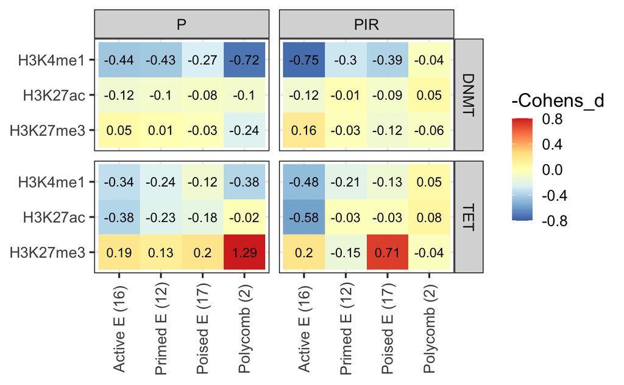